# Term Deposit Sale

## Data Preparation

```python
def missing_check(df):
    total = df.isnull().sum().sort_values(ascending=False)
    percent = (df.isnull().sum()/df.isnull().count()).sort_values(ascending=False)
    md = pd.concat([total, percent], axis=1, keys=['Total', 'Percent'])

    return md

missing_check(data)
```

|  | Total | Percent |
| --- | --- | --- |
| Target | 0 | 0.0 |
| loan | 0 | 0.0 |
| job | 0 | 0.0 |
| marital | 0 | 0.0 |
| education | 0 | 0.0 |
| default | 0 | 0.0 |
| balance | 0 | 0.0 |
| housing | 0 | 0.0 |
| contact | 0 | 0.0 |
| poutcome | 0 | 0.0 |
| day | 0 | 0.0 |
| month | 0 | 0.0 |
| duration | 0 | 0.0 |
| campaign | 0 | 0.0 |
| pdays | 0 | 0.0 |
| previous | 0 | 0.0 |
| age | 0 | 0.0 |

```python
dupes = data.duplicated()
sum(dupes)
```

```
0
```

*No duplicate rows*

```python
pd.DataFrame(data.isnull().sum(), columns=['Number of missing values'])
```

|  | Number of missing values |
| --- | --- |
| age | 0 |
| job | 0 |
| marital | 0 |
| education | 0 |
| default | 0 |
| balance | 0 |
| housing | 0 |
| loan | 0 |
| contact | 0 |
| day | 0 |
| month | 0 |
| duration | 0 |
| campaign | 0 |
| pdays | 0 |
| previous | 0 |
| poutcome | 0 |
| Target | 0 |

*No missing values*

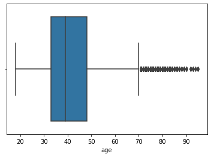

```python
sns.boxplot(x=data['age']);
```

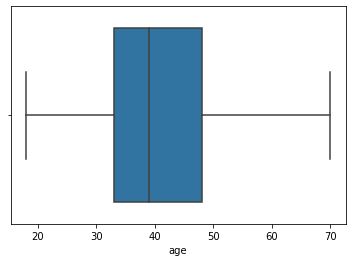

```python
data_no = data_no[data_no['age'] <= 70]

sns.boxplot(x=data_no['age']);
```

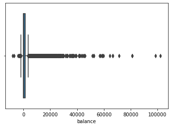

```python
sns.boxplot(x=data['balance']);
```

*Data here is too spread out to reliably remove outliers; no change.*

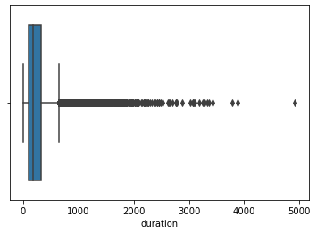

```python
sns.boxplot(x=data['duration']);
```

*Data here is too spread out to reliably remove outliers; no change.*

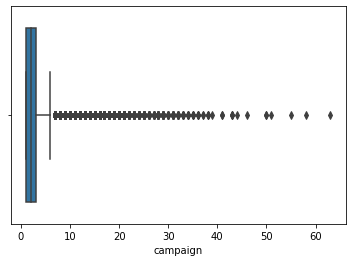

```python
sns.boxplot(x=data['campaign']);
```

```python
data['campaign'].describe()
```

```
count    45211.000000
mean         2.763841
std          3.098021
min          1.000000
25%          1.000000
50%          2.000000
75%          3.000000
max         63.000000
Name: campaign, dtype: float64
```

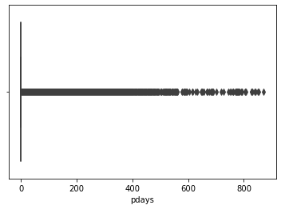

```python
sns.boxplot(x=data['pdays']);
```

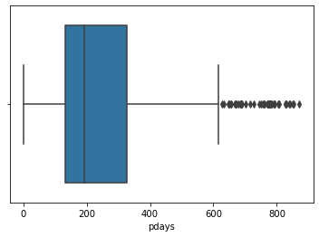

```python
pdays_no_neg = data['pdays'].replace(-1, np.nan)

sns.boxplot(x=pdays_no_neg);
```

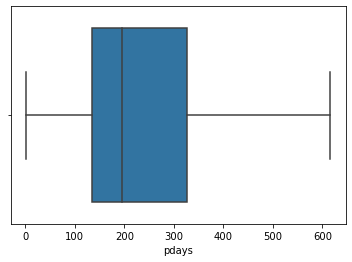

```python
data_no['pdays'] = data_no['pdays'].replace(-1, np.nan)
data_no = data_no[data_no['pdays'] <= 625]

sns.boxplot(x=data_no['pdays']);
```

*Compare the correlations between our two datasets*

```python
def plot_corr(df, size=11):
    corr = df.corr()
    fig, ax = plt.subplots(figsize=(size, size))
    ax.matshow(corr)
    plt.xticks(range(len(corr.columns)), corr.columns)
    plt.yticks(range(len(corr.columns)), corr.columns)
    for (i, j), z in np.ndenumerate(corr):
        ax.text(j, i, '{:0.1f}'.format(z), ha='center', va='center')
```

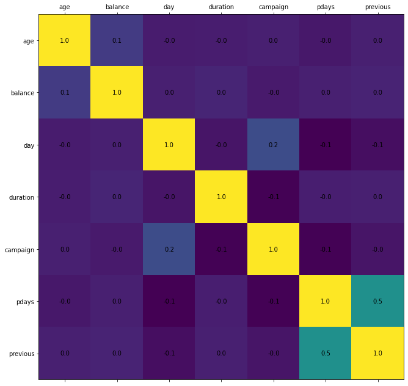

```python
plot_corr(data)
```

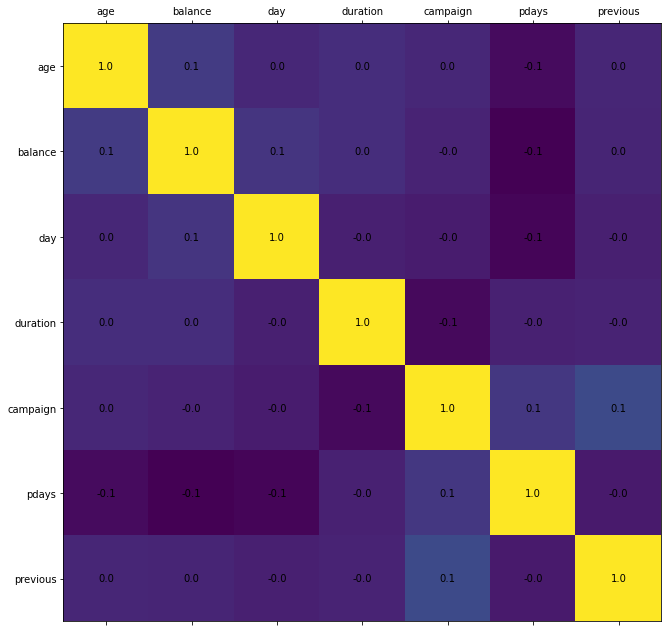

```python
plot_corr(data_no)
```

*Thoughts*:

It looks like removing outliers removes things that indicate correlation, so we're going to stick to using `data`, not `data_no`.

```python
onehot_cols = ['job','marital','contact','month']

data = pd.get_dummies(data, columns=onehot_cols)
```

```python
data.head()
```

|  | age | education | default | balance | housing | loan | day | duration | campaign | pdays | previous | poutcome | Target | job_admin. | job_blue-collar | job_entrepreneur | job_housemaid | job_management | job_retired | job_self-employed | job_services | job_student | job_technician | job_unemployed | job_unknown | marital_divorced | marital_married | marital_single | contact_cellular | … |
| --- | --- | --- | --- | --- | --- | --- | --- | --- | --- | --- | --- | --- | --- | --- | --- | --- | --- | --- | --- | --- | --- | --- | --- | --- | --- | --- | --- | --- | --- | --- |
| 0 | 58 | tertiary | no | 2143 | yes | no | 5 | 261 | 1 | -1 | 0 | unknown | no | 0 | 0 | 0 | 0 | 1 | 0 | 0 | 0 | 0 | 0 | 0 | 0 | 0 | 1 | 0 | 0 | … |
| 1 | 44 | secondary | no | 29 | yes | no | 5 | 151 | 1 | -1 | 0 | unknown | no | 0 | 0 | 0 | 0 | 0 | 0 | 0 | 0 | 0 | 1 | 0 | 0 | 0 | 0 | 1 | 0 | … |
| 2 | 33 | secondary | no | 2 | yes | yes | 5 | 76 | 1 | -1 | 0 | unknown | no | 0 | 0 | 1 | 0 | 0 | 0 | 0 | 0 | 0 | 0 | 0 | 0 | 0 | 1 | 0 | 0 | … |
| 3 | 47 | unknown | no | 1506 | yes | no | 5 | 92 | 1 | -1 | 0 | unknown | no | 0 | 1 | 0 | 0 | 0 | 0 | 0 | 0 | 0 | 0 | 0 | 0 | 0 | 1 | 0 | 0 | … |
| 4 | 33 | unknown | no | 1 | no | no | 5 | 198 | 1 | -1 | 0 | unknown | no | 0 | 0 | 0 | 0 | 0 | 0 | 0 | 0 | 0 | 0 | 0 | 1 | 0 | 0 | 1 | 0 | … |

```python
replaceStruct = {
    'Target': {
        'no': 0,
        'yes': 1
    },
    'education': {
        'unknown': -1,
        'primary': 1,
        'secondary': 2,
        'tertiary': 3
    },
    'default': {
        'no': 0,
        'yes': 1
    },
    'housing': {
        'no': 0,
        'yes': 1
    },
    'loan': {
        'no': 0,
        'yes': 1
    },
    'poutcome': {
        'failure': -1,
        'unknown': 0,
        'other': 1,
        'success': 2
    }
}

data = data.replace(replaceStruct)
```

```python
data.info()
```

```
<class 'pandas.core.frame.DataFrame'>
RangeIndex: 45211 entries, 0 to 45210
Data columns (total 43 columns):
 #   Column             Non-Null Count  Dtype
---  ------             --------------  -----
 0   age                45211 non-null  int64
 1   education          45211 non-null  int64
 2   default            45211 non-null  int64
 3   balance            45211 non-null  int64
 4   housing            45211 non-null  int64
 5   loan               45211 non-null  int64
 6   day                45211 non-null  int64
 7   duration           45211 non-null  int64
 8   campaign           45211 non-null  int64
 9   pdays              45211 non-null  int64
```

[output cut: 35 more lines]

```python
x = data.drop('Target', axis=1)
y = data.pop('Target')
```

```python
x_train, x_test, y_train, y_test = tts(x, y, test_size=.3, random_state=1)
```

## Models

### Logistic Regression

```python
from sklearn.linear_model import LogisticRegression
```

```python
def calc_precision(tp, fp):
    return tp/(tp+fp)

def calc_recall(tp, fn):
    return tp/(tp+fn)

def calc_f1(tp, fp, fn):
    p = calc_precision(tp, fp)
    r = calc_recall(tp, fn)
    return 2*((p*r)/(p+r))
```

```python
lr_model = LogisticRegression(solver="liblinear")
lr_model.fit(x_train, y_train)

y_predict = lr_model.predict(x_test)

lr_coef_df = pd.DataFrame(lr_model.coef_)
lr_coef_df['intercept'] = lr_model.intercept_

lr_coef_df
```

```
LogisticRegression(solver='liblinear')
```

|  | 0 | 1 | 2 | 3 | 4 | 5 | 6 | 7 | 8 | 9 | 10 | 11 | 12 | 13 | 14 | 15 | 16 | 17 | 18 | 19 | 20 | 21 | 22 | 23 | 24 | 25 | 26 | 27 | 28 | … |
| --- | --- | --- | --- | --- | --- | --- | --- | --- | --- | --- | --- | --- | --- | --- | --- | --- | --- | --- | --- | --- | --- | --- | --- | --- | --- | --- | --- | --- | --- | --- |
| 0 | -0.00199 | 0.089793 | -0.246676 | 0.000017 | -0.722379 | -0.455985 | 0.00672 | 0.004262 | -0.103578 | 0.00122 | 0.036894 | 0.700077 | 0.016403 | -0.388112 | -0.454635 | -0.492557 | -0.10792 | 0.312391 | -0.261074 | -0.237943 | 0.398316 | -0.175013 | -0.268883 | -0.047911 | -0.568692 | -0.694014 | -0.444233 | 0.03939 | -0.119824 | … |

```python
lr_model_score = lr_model.score(x_test, y_test)
lr_model_score
```

```
0.8995871424358596
```

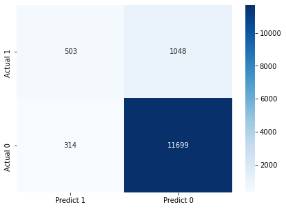

```python
y_predict = lr_model.predict(x_test)

lr_cm = metrics.confusion_matrix(y_test, y_predict, labels=[1,0])

lr_df_cm = pd.DataFrame(lr_cm, index=[i for i in ["Actual 1","Actual 0"]], columns=[i for i in ["Predict 1", "Predict 0"]])

plt.figure(figsize=(7,5));

sns.heatmap(lr_df_cm, annot=True, cmap='Blues', fmt='d');
```

#### Logistic Regression Metrics

```python
lr_tp = 503
lr_fp = 314
lr_fn = 1048

print('Accuracy: ' + str(lr_model_score))
print('Precision: ' + str(calc_precision(lr_tp, lr_fp)))
print('Recall: ' + str(calc_recall(lr_tp, lr_fn)))
print('F1: ' + str(calc_f1(lr_tp, lr_fn, lr_fp)))
```

```
Accuracy: 0.8995871424358596
Precision: 0.6156670746634026
Recall: 0.32430689877498386
F1: 0.42483108108108103
```

```python
labels = ['Accuracy', 'Precision', 'Recall', 'F1']
s_lr = pd.Series(data=[lr_model_score, calc_precision(lr_tp, lr_fp), calc_recall(lr_tp, lr_fn), calc_f1(lr_tp, lr_fn, lr_fp)],
                 index=labels)

model_comparison = pd.DataFrame(s_lr, columns=['Logistic'])
```

### Decision Tree

```python
dt_model = DecisionTreeClassifier(criterion='gini', random_state=1)
dt_model.fit(x_train, y_train)
```

```
DecisionTreeClassifier(random_state=1)
```

```python
print(dt_model.score(x_train, y_train))
print(dt_model.score(x_test, y_test))
```

```
1.0
0.8779121203184901
```

```python
dt_model = DecisionTreeClassifier(criterion='gini', random_state=1, max_depth=7)
dt_model.fit(x_train, y_train)

dt_model_score = dt_model.score(x_test, y_test)

print(dt_model.score(x_train, y_train))
print(dt_model.score(x_test, y_test))
```

```
DecisionTreeClassifier(max_depth=7, random_state=1)
```

```
0.9127879419850222
0.9025361250368623
```

```python
pd.DataFrame(dt_model.feature_importances_, columns=['Imp'], index=x_train.columns)
```

|  | Imp |
| --- | --- |
| age | 0.053852 |
| education | 0.001688 |
| default | 0.000000 |
| balance | 0.004807 |
| housing | 0.006953 |
| loan | 0.002822 |
| day | 0.017691 |
| duration | 0.516740 |
| campaign | 0.007044 |
| pdays | 0.034519 |
| previous | 0.002668 |
| poutcome | 0.242389 |
| job_admin. | 0.001711 |
| job_blue-collar | 0.000394 |
| job_entrepreneur | 0.000000 |
| job_housemaid | 0.000000 |
| job_management | 0.001697 |
| job_retired | 0.000697 |
| job_self-employed | 0.000000 |
| job_services | 0.000000 |
| job_student | 0.000000 |
| job_technician | 0.001357 |
| job_unemployed | 0.000557 |
| job_unknown | 0.000689 |
| marital_divorced | 0.001741 |
| marital_married | 0.001458 |
| marital_single | 0.000000 |
| contact_cellular | 0.004206 |
| contact_telephone | 0.000000 |
| contact_unknown | 0.014529 |
| month_apr | 0.000989 |
| month_aug | 0.001355 |
| month_dec | 0.001272 |
| month_feb | 0.000571 |
| month_jan | 0.000000 |
| month_jul | 0.000000 |
| month_jun | 0.005436 |
| month_mar | 0.029082 |
| month_may | 0.009616 |
| month_nov | 0.001317 |
| month_oct | 0.027203 |
| month_sep | 0.002954 |

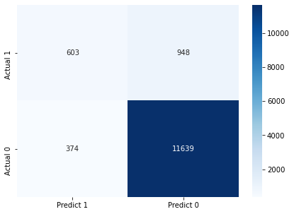

```python
y_predict = dt_model.predict(x_test)

dt_cm = metrics.confusion_matrix(y_test, y_predict, labels=[1,0])

dt_df_cm = pd.DataFrame(dt_cm, index=[i for i in ["Actual 1","Actual 0"]], columns=[i for i in ["Predict 1", "Predict 0"]])

plt.figure(figsize=(7,5));

sns.heatmap(dt_df_cm, annot=True, cmap='Blues', fmt='d');
```

#### Decision Tree Metrics

```python
dt_tp = 603
dt_fp = 374
dt_fn = 948

print('Accuracy: ' + str(lr_model_score))
print('Precision: ' + str(calc_precision(dt_tp, dt_fp)))
print('Recall: ' + str(calc_recall(dt_tp, dt_fn)))
print('F1: ' + str(calc_f1(dt_tp, dt_fn, dt_fp)))
```

```
Accuracy: 0.8995871424358596
Precision: 0.617195496417605
Recall: 0.38878143133462284
F1: 0.47705696202531644
```

```python
s_dt = pd.Series(data=[dt_model_score, calc_precision(dt_tp, dt_fp), calc_recall(dt_tp, dt_fn), calc_f1(dt_tp, dt_fn, dt_fp)],
                 index=labels)

model_comparison['Decision Tree'] = s_dt
```

### Ensemble Models

#### Bagging

```python
from sklearn.ensemble import BaggingClassifier
```

```python
bag_model = BaggingClassifier(base_estimator=dt_model, n_estimators=50, random_state=1)
bag_model = bag_model.fit(x_train, y_train)
```

```python
y_predict = bag_model.predict(x_test)

bag_model_score = bag_model.score(x_test, y_test)

bag_model_score
```

```
0.90555883220289
```

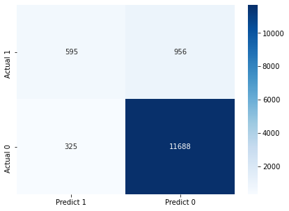

```python
bag_cm = metrics.confusion_matrix(y_test, y_predict, labels=[1,0])

bag_df_cm = pd.DataFrame(bag_cm, index=[i for i in ["Actual 1","Actual 0"]], columns=[i for i in ["Predict 1", "Predict 0"]])

plt.figure(figsize=(7,5));

sns.heatmap(bag_df_cm, annot=True, cmap='Blues', fmt='d');
```

##### Bagging Metrics

```python
bag_tp = 595
bag_fp = 325
bag_fn = 956

print('Accuracy: ' + str(bag_model_score))
print('Precision: ' + str(calc_precision(bag_tp, bag_fp)))
print('Recall: ' + str(calc_recall(bag_tp, bag_fn)))
print('F1: ' + str(calc_f1(bag_tp, bag_fn, bag_fp)))
```

```
Accuracy: 0.90555883220289
Precision: 0.6467391304347826
Recall: 0.3836234687298517
F1: 0.4815864022662889
```

```python
bag_dt = pd.Series(data=[bag_model_score, calc_precision(bag_tp, bag_fp), calc_recall(bag_tp, bag_fn), calc_f1(bag_tp, bag_fn, bag_fp)],
                   index=labels)

model_comparison['Bagging'] = bag_dt
```

#### Boosting (AdaBoosting and GradientBoost)

```python
from sklearn.ensemble import AdaBoostClassifier
```

```python
ab_model = AdaBoostClassifier(n_estimators=10, random_state=1)
ab_model = ab_model.fit(x_train, y_train)
```

```python
y_predict = ab_model.predict(x_test)

ab_model_score = ab_model.score(x_test, y_test)
ab_model_score
```

```
0.8948687702742554
```

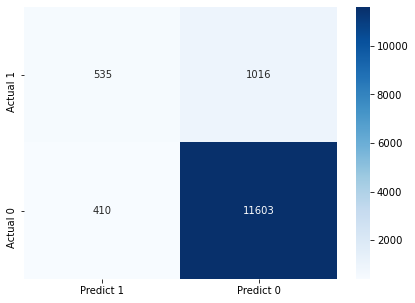

```python
ab_cm = metrics.confusion_matrix(y_test, y_predict, labels=[1,0])

ab_df_cm = pd.DataFrame(ab_cm, index=[i for i in ["Actual 1","Actual 0"]], columns=[i for i in ["Predict 1", "Predict 0"]])

plt.figure(figsize=(7,5));

sns.heatmap(ab_df_cm, annot=True, cmap='Blues', fmt='d');
```

```python
from sklearn.ensemble import GradientBoostingClassifier
```

```python
gb_model = GradientBoostingClassifier(n_estimators=50, random_state=1)
gb_model = gb_model.fit(x_train, y_train)
```

```python
y_predict = gb_model.predict(x_test)

gb_model_score = gb_model.score(x_test, y_test)
gb_model_score
```

```
0.9046741374225892
```

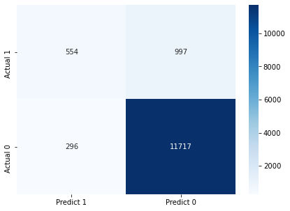

```python
gb_cm = metrics.confusion_matrix(y_test, y_predict, labels=[1,0])

gb_df_cm = pd.DataFrame(gb_cm, index=[i for i in ["Actual 1", "Actual 0"]], columns=[i for i in ["Predict 1", "Predict 0"]])

plt.figure(figsize=(7,5));

sns.heatmap(gb_df_cm, annot=True, cmap='Blues', fmt='d');
```

##### Boosting Metrics

```python
ab_tp = 535
ab_fp = 410
ab_fn = 1016

print('Accuracy: ' + str(ab_model_score))
print('Precision: ' + str(calc_precision(ab_tp, ab_fp)))
print('Recall: ' + str(calc_recall(ab_tp, ab_fn)))
print('F1: ' + str(calc_f1(ab_tp, ab_fn, ab_fp)))
```

```
Accuracy: 0.8948687702742554
Precision: 0.5661375661375662
Recall: 0.34493874919406836
F1: 0.4286858974358974
```

```python
gb_tp = 554
gb_fp = 296
gb_fn = 997

print('Accuracy: ' + str(gb_model_score))
print('Precision: ' + str(calc_precision(gb_tp, gb_fp)))
print('Recall: ' + str(calc_recall(gb_tp, gb_fn)))
print('F1: ' + str(calc_f1(gb_tp, gb_fn, gb_fp)))
```

```
Accuracy: 0.9046741374225892
Precision: 0.6517647058823529
Recall: 0.35718891038039974
F1: 0.46147438567263643
```

```python
ab_dt = pd.Series(data=[ab_model_score, calc_precision(ab_tp, ab_fp), calc_recall(ab_tp, ab_fn), calc_f1(ab_tp, ab_fn, ab_fp)],
                  index=labels)

gb_dt = pd.Series(data=[ab_model_score, calc_precision(gb_tp, gb_fp), calc_recall(gb_tp, gb_fn), calc_f1(gb_tp, gb_fn, gb_fp)],
                  index=labels)

model_comparison['AdaBoost'] = ab_dt
model_comparison['Gradient Boost'] = gb_dt
```

#### RandomForest Classifier

```python
from sklearn.ensemble import RandomForestClassifier
```

```python
rf_model = RandomForestClassifier(n_estimators=50, random_state=1, max_features=12)
rf_model = rf_model.fit(x_train, y_train)
```

```python
y_predict = rf_model.predict(x_test)

rf_model_score = rf_model.score(x_test, y_test)
rf_model_score
```

```
0.907844293718667
```

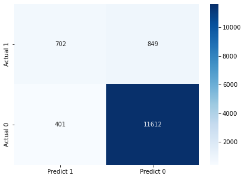

```python
rf_cm = metrics.confusion_matrix(y_test, y_predict, labels=[1,0])

rf_df_cm = pd.DataFrame(rf_cm, index=[i for i in ["Actual 1", "Actual 0"]], columns=[i for i in ["Predict 1", "Predict 0"]])

plt.figure(figsize=(7,5));

sns.heatmap(rf_df_cm, annot=True, cmap='Blues', fmt='d');
```

##### RandomForest Metrics

```python
rf_tp = 702
rf_fp = 401
rf_fn = 849

print('Accuracy: ' + str(rf_model_score))
print('Precision: ' + str(calc_precision(rf_tp, rf_fp)))
print('Recall: ' + str(calc_recall(rf_tp, rf_fn)))
print('F1: ' + str(calc_f1(rf_tp, rf_fn, rf_fp)))
```

```
Accuracy: 0.907844293718667
Precision: 0.6364460562103355
Recall: 0.4526112185686654
F1: 0.5290128108515448
```

```python
rf_dt = pd.Series(data=[rf_model_score, calc_precision(rf_tp, rf_fp), calc_recall(rf_tp, rf_fn), calc_f1(rf_tp, rf_fn, rf_fp)],
                  index=labels)

model_comparison['RandomForest'] = rf_dt
```

### Model Comparison

```python
model_comparison
```

[output not shown]

#### Model Analysis

Our objective here is to identify customers who are more likely to subscribe to term deposits. As the relative cost of a false positive - identifying a prospect who ultimately does not subscribe - is low, and has no negative impact on the business, we want to maximize identification of possible customers.